# Activity: Popular Names

Daniel Gao

June 4, 2023

# Grading

Assignment is worth a total of 10 points

- [1 point] Turn in BOTH RNotebook (.nb.html) and the RMarkdown (.Rmd) file to Canvas
- [1 point] Changes pushed to GitHub
- [1 point] Step 1: show how you used summary functions to explore the raw data set
- [1 point] Step 3 and 4: attempt to answer all questions about the data
- [1 point] Step 5: explanation of data wrangling steps in English (not code)
- [3 points] Step 7: Data wrangling
  - correct use of `filter()`
  - correct use of `group_by()`
  - correct use of `summarise()`
- [2 points] `ggplot()` graph of first names

# Set Up

```r
# load necessary packages
library(tidyverse)
library(mosaic)
library(esquisse)


# Load the BabyNames data into RStudio environment (from dcData package)
data("BabyNames", package = "dcData")
```

# Activity

**Goal**: By the end of the activity, each team will create a graph (like Figure A.1 on p 159) showing ups and downs in the popularity of the names at your table according to the U.S. social security registry.

### Step 1

*Examine the data you have at hand - for this project the data are the ones available in the `BabyNames` data set. Use at least 2 different functions to examine your data. Then answer the questions: What are the variables are available? What is a case?*

My answer here…. The variables are name, sex, count, and year. A case would be the number of babies for each name and for each year.

```r
## Look at the data a few different ways (see Ch 9 for more).
summary(BabyNames)
```

```
     name               sex                count            year
 Length:1792091     Length:1792091     Min.   :    5   Min.   :1880
 Class :character   Class :character   1st Qu.:    7   1st Qu.:1948
 Mode  :character   Mode  :character   Median :   12   Median :1981
                                       Mean   :  186   Mean   :1972
                                       3rd Qu.:   32   3rd Qu.:2000
                                       Max.   :99674   Max.   :2013
```

```r
view(BabyNames)
```

### Step 2

[This should be done by hand on paper, nothing to show in the HTML doc]

### Step 3

##### What variable(s) from the raw data table do not appear at all in the graph?

My answer here…. The variable that would not appear would be sex.

##### What variable(s) in the graph are similar to corresponding variables in the raw data table, but might have been transformed in some way?

My answer here…. The variable sex is not in the graph so this variable has to be transformed. To disregard sex in this graph, a group_by function would be needed containing name and year. Then a summarise function would contain the sum of the count of each name per year.

### Step 4

##### Have cases been filtered out?

My answer here…. Yes, all the cases excluding the names I picked (Anna, Mary, Emma, Ida, Clara).

##### Have cases been grouped and summarized within groups in any way?

My answer here…. Yes, cases have been grouped by name, and year and summarised to the sum of the count of each name per year.

##### Have any new variables been introduced? If so, what the relationship between the new variables and existing variables?

My answer here…. A new variable was introduced named total, as it was the sum of the total count of each baby name per year regardless of sex.

### Step 5

Using the BabyNames data set, filter the data to display just the 5 names that you picked. Then group the cases by year and name, and count how many total births per year were recorded for each of the names (regardless of sex).

```r
BabyNames %>%
  filter(name == "Anna" | name == "Mary" | name == "Emma" | name == "Ida" | name == "Clara") %>%
  group_by(name,year) %>%
  summarise(total = sum(count))
```

| name | year | total |
| --- | --- | --- |
| Anna | 1880 | 2616 |
| Anna | 1881 | 2714 |
| Anna | 1882 | 3143 |
| Anna | 1883 | 3322 |
| Anna | 1884 | 3880 |
| Anna | 1885 | 4014 |
| Anna | 1886 | 4298 |
| Anna | 1887 | 4239 |
| Anna | 1888 | 5008 |
| Anna | 1889 | 5085 |

[output cut: 660 more lines]

### Step 6

[This should be done by hand on paper, nothing to show in the HTML doc]

### Step 7

```r
## Create my glyph ready data set here

GlyphReadyForm <-
  BabyNames %>%
  filter(
    name == "Anna" | name == "Mary" | name == "Emma" | name == "Ida" | name == "Clara"
    ) %>%
  group_by(name,year) %>%
  summarise(total = sum(count))
# inspect the result
GlyphReadyForm
```

| name | year | total |
| --- | --- | --- |
| Anna | 1880 | 2616 |
| Anna | 1881 | 2714 |
| Anna | 1882 | 3143 |
| Anna | 1883 | 3322 |
| Anna | 1884 | 3880 |
| Anna | 1885 | 4014 |
| Anna | 1886 | 4298 |
| Anna | 1887 | 4239 |
| Anna | 1888 | 5008 |
| Anna | 1889 | 5085 |

[output cut: 660 more lines]

```r
NA
```

### Graph It!

Here’s the sample code provided by the book:

```
GlyphReadyForm %>%
  ggplot(aes(x = year, y = total, group = name)) +
  geom_line(size = 1, alpha = 0.5, aes(color = name)) +
  ylab("Popularity") +
  xlab("Year") +
  ggtitle("Popularity of Names Over Time")
```

If you prepared your `GlyphReadyForm` data set correctly, you should just be able to copy and paste this code. Alternatively, you can use `mplot` or `esquisse` to create your graph. If you choose to use these interactive functions remember, do not include the `mplot` or `esquisse` functions in your RMarkdown document. Instead, use these functions in the console and copy the generated code into your RMarkkdown document. In addition, we want lines, not dots. See examples below.

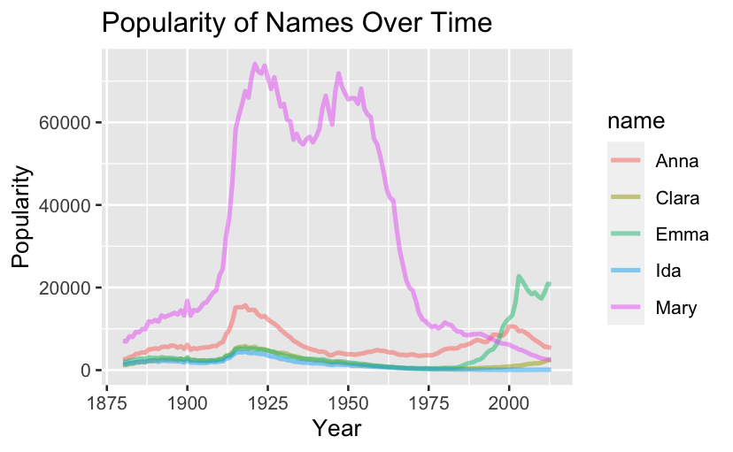

```r
#My code here
GlyphReadyForm %>%
  ggplot(aes(x = year, y = total, group = name)) +
  geom_line(size = 1, alpha = 0.5, aes(color = name)) +
  ylab("Popularity") +
  xlab("Year") +
  ggtitle("Popularity of Names Over Time")
```

#### Example of Dots versus Lines

We can create a scatter plot for our graph. It’s close to what we want, but the line plot that we really want as it is easier to understand.

```
ggplot( data = GlyphReadyForm, aes(x = year, y = total) ) +
  geom_point()+
  aes(colour = name)
```

```
GlyphReadyForm %>%
  ggplot(aes(x = year, y = total, group = name)) +
  geom_line(size = 1, alpha = 0.5, aes(color = name)) +
  ylab("Popularity") +
  xlab("Year")
```